# IA para Científicos Sociales

Sesión 1.3: Laboratorio 1 - Primer flujo de trabajo con tidymodels

Danilo Freire

danilofreire@gmail.com

Department of Data and Decision Sciences  
Emory University

# Laboratorio 1: Primer flujo de trabajo con tidymodels

## Objetivos del laboratorio

**Lo que vamos a hacer:**

1. Configurar el entorno de trabajo
2. Cargar y explorar datos
3. Preprocesar variables
4. Dividir datos (train/test)
5. Entrenar un modelo de clasificación
6. Evaluar el rendimiento
7. Interpretar resultados

**Lo que vamos a aprender:**

- El ecosistema [tidymodels](https://www.tidymodels.org/)
- El flujo completo de ML en R
- Cómo evaluar un clasificador
- Buenas prácticas de reproducibilidad

Trabajen en sus computadoras y pregunten si tienen dudas 😉

# Parte 1: Configuración y exploración

## Configuración del entorno

Necesitamos instalar y cargar los paquetes. Ejecuten este código en R:

```r
# Instalar paquetes (solo la primera vez)
install.packages(c("tidymodels", "tidyverse"))

# Cargar paquetes
library(tidymodels)
library(tidyverse)
```

- Si ya tienen tidyverse instalado, solo necesitan instalar tidymodels
- tidymodels carga automáticamente: [rsample](https://rsample.tidymodels.org/), [parsnip](https://parsnip.tidymodels.org/), [yardstick](https://yardstick.tidymodels.org/), y otros paquetes que necesitaremos
- Si la instalación falla, intenten:

```r
install.packages("tidymodels", dependencies = TRUE)
```

## Recapitulando: el ecosistema tidy

[tidymodels](https://www.tidymodels.org/) es un conjunto de paquetes que comparten la filosofía del tidyverse. Los que usaremos hoy:

- [rsample:](https://rsample.tidymodels.org/) división de datos
- [parsnip:](https://parsnip.tidymodels.org/) especificación de modelos
- [yardstick:](https://yardstick.tidymodels.org/) métricas de evaluación

Ventaja: misma sintaxis para cualquier modelo, sea regresión logística, random forest o redes neuronales. La [lista completa](https://www.tidymodels.org/packages/) queda en la documentación

## Cargar los datos

Vamos a trabajar con un dataset de indicadores socioeconómicos de países de todo el mundo (datos simulados inspirados en el Banco Mundial):

- Es un corte transversal (cross-section): una observación por país, sin dimensión temporal
- Los datos fueron generados a partir de un factor latente de “desarrollo” con ruido propio por indicador, lo que produce correlaciones moderadas entre predictores (r ~ 0.10-0.40)

```r
# Cargar los datos
datos <- read_csv("datos/indicadores_mundiales.csv")
# Lean el archivo directo desde la web:
# datos <- read_csv("https://raw.githubusercontent.com/danilofreire/introduccion-ia-ucu/main/clases/dia-01/datos/indicadores_mundiales.csv")

# Ver las primeras filas
glimpse(datos)
```

```
Rows: 179
Columns: 11
$ pais                    <chr> "Angola", "Argelia", "Benín", "Botsuana", "Bur…
$ continente              <chr> "África", "África", "África", "África", "Áfric…
$ gasto_educacion         <dbl> 5.7, 4.0, 3.2, 5.0, 4.6, 4.8, 4.6, 4.3, 5.9, 5…
$ acceso_internet         <dbl> 50.2, 48.0, 34.3, 46.2, 62.5, 66.0, 55.5, 39.1…
$ urbanizacion            <dbl> 69.1, 61.8, 62.9, 68.6, 54.5, 32.3, 57.6, 52.1…
$ gasto_salud             <dbl> 8.3, 7.6, 4.5, 5.5, 4.3, 4.6, 8.3, 6.9, 4.8, 6…
$ inflacion               <dbl> 9.4, 9.2, 10.3, 14.7, 12.2, 11.8, 11.2, 23.4, …
$ desempleo               <dbl> 5.9, 10.0, 7.2, 13.1, 12.7, 9.7, 9.5, 14.0, 9.…
$ inversion_extranjera    <dbl> 2.4, 4.8, 2.5, 4.1, 2.3, 2.3, 5.5, 3.6, 5.2, 1…
$ indice_gobierno_digital <dbl> 0.38, 0.78, 0.13, 0.49, 0.52, 0.33, 0.57, 0.33…
$ crecimiento_alto        <chr> "si", "si", "no", "no", "no", "si", "no", "no"…
```

## Exploración inicial

Antes de modelar, siempre hay que explorar los datos:

```r
# Resumen estadístico
summary(datos)
```

```
        pais         continente  gasto_educacion acceso_internet
 Length   :179   Length   :179   Min.   :2.100   Min.   : 5.00
 N.unique :179   N.unique :  5   1st Qu.:4.400   1st Qu.:46.60
 N.blank  :  0   N.blank  :  0   Median :5.000   Median :57.50
 Min.nchar:  4   Min.nchar:  4   Mean   :5.027   Mean   :57.52
 Max.nchar: 20   Max.nchar:  7   3rd Qu.:5.600   3rd Qu.:68.35
                                 Max.   :8.000   Max.   :99.00
  urbanizacion    gasto_salud      inflacion       desempleo
 Min.   :16.40   Min.   :3.200   Min.   : 5.20   Min.   : 1.500
 1st Qu.:44.70   1st Qu.:5.800   1st Qu.: 9.35   1st Qu.: 6.700
 Median :58.10   Median :6.700   Median :11.70   Median : 8.400
 Mean   :58.42   Mean   :6.631   Mean   :12.73   Mean   : 8.434
 3rd Qu.:73.15   3rd Qu.:7.450   3rd Qu.:14.70   3rd Qu.:10.100
 Max.   :97.60   Max.   :9.500   Max.   :37.40   Max.   :16.100
 inversion_extranjera indice_gobierno_digital  crecimiento_alto
 Min.   :0.200        Min.   :0.0800          Length   :179
 1st Qu.:3.050        1st Qu.:0.4050          N.unique :  2
 Median :4.200        Median :0.5200          N.blank  :  0
 Mean   :4.079        Mean   :0.5136          Min.nchar:  2
 3rd Qu.:5.100        3rd Qu.:0.6350          Max.nchar:  2
 Max.   :7.400        Max.   :0.9600
```

## Explorar la variable de resultado

- **Problema**: predecir si un país tendrá crecimiento alto del PIB (>= 3%) en un año dado
- **Variable de resultado**: `crecimiento_alto` (sí/no)
- **Predictores**: gasto en educación, acceso a internet, urbanización, gasto en salud, inflación, desempleo, inversión extranjera, índice de gobierno digital
- Esto es un problema de clasificación binaria
- Nota: |> es el operador de pipe nativo de R 4.1+ (la fuente de estas diapositivas tiene ligaduras tipográficas, por eso se ve diferente)

```r
# Verificar la distribución
# del outcome
datos |>
  count(crecimiento_alto) |>
  mutate(prop = n / sum(n))
```

```
# A tibble: 2 × 3
  crecimiento_alto     n  prop
  <chr>            <int> <dbl>
1 no                  93 0.520
2 si                  86 0.480
```

## Ejercicio 1: Exploración

**Instrucciones:** Antes de continuar, exploren los datos ustedes mismos

1. ¿Cuántas observaciones y variables tiene el dataset?
2. ¿Hay valores faltantes (NA)?
3. ¿Cómo se distribuye cada variable numérica?
4. ¿Hay correlaciones fuertes entre las variables?

Pista: estos comandos les sirven para las cuatro preguntas. ¡Tómense unos minutos para explorar! 🤓

```r
dim(datos)              # 1. filas y columnas
glimpse(datos)          #    tipo de cada variable

sum(is.na(datos))       # 2. total de valores faltantes
colSums(is.na(datos))   #    faltantes por columna

datos |>                # 3. mínimo, mediana, máximo de cada variable
  select(where(is.numeric)) |> summary()

datos |>                # 4. correlaciones entre predictores
  select(where(is.numeric)) |> cor() |> round(2)
```

Apéndice 1: Solución

# Parte 2: Preprocesamiento y división

## Preparar los datos

Convertimos la variable de resultado a factor y descartamos las columnas que no usaremos como predictores (`pais` tiene 179 valores únicos y rompería el modelo; `continente` la dejamos fuera para mantenernos en predictores numéricos):

```r
datos_modelo <- datos |>
  mutate(crecimiento_alto = factor(crecimiento_alto, levels = c("no", "si"))) |>
  select(-pais, -continente)

glimpse(datos_modelo)
```

```
Rows: 179
Columns: 9
$ gasto_educacion         <dbl> 5.7, 4.0, 3.2, 5.0, 4.6, 4.8, 4.6, 4.3, 5.9, 5…
$ acceso_internet         <dbl> 50.2, 48.0, 34.3, 46.2, 62.5, 66.0, 55.5, 39.1…
$ urbanizacion            <dbl> 69.1, 61.8, 62.9, 68.6, 54.5, 32.3, 57.6, 52.1…
$ gasto_salud             <dbl> 8.3, 7.6, 4.5, 5.5, 4.3, 4.6, 8.3, 6.9, 4.8, 6…
$ inflacion               <dbl> 9.4, 9.2, 10.3, 14.7, 12.2, 11.8, 11.2, 23.4, …
$ desempleo               <dbl> 5.9, 10.0, 7.2, 13.1, 12.7, 9.7, 9.5, 14.0, 9.…
$ inversion_extranjera    <dbl> 2.4, 4.8, 2.5, 4.1, 2.3, 2.3, 5.5, 3.6, 5.2, 1…
$ indice_gobierno_digital <dbl> 0.38, 0.78, 0.13, 0.49, 0.52, 0.33, 0.57, 0.33…
$ crecimiento_alto        <fct> si, si, no, no, no, si, no, no, si, no, no, no…
```

## ¿Por qué convertir a factor?

- En R, los modelos de clasificación esperan que la variable objetivo sea un factor
- Un factor es un tipo de dato para variables categóricas
- Tiene niveles ordenados: el primer nivel es la clase “negativa”
- En nuestro caso: `levels = c("no", "si")`
  - “no” = clase negativa (referencia)
  - “si” = clase positiva (la que queremos predecir)
  - Usamos `levels(...)` para asegurarnos de que el orden es correcto
- El orden importa para interpretar métricas como precisión y recall

```r
# Ver los niveles del factor
levels(datos_modelo$crecimiento_alto)
```

```
[1] "no" "si"
```

## Dividir los datos

Usamos `initial_split()` de rsample para crear la [división train/test](https://rsample.tidymodels.org/reference/initial_split.html):

```r
# Fijar semilla para reproducibilidad
set.seed(2026)

# Dividir: 75% entrenamiento, 25% prueba
datos_split <- initial_split(datos_modelo, prop = 0.75, strata = crecimiento_alto)

# Extraer los conjuntos
datos_train <- training(datos_split)
datos_test  <- testing(datos_split)

# Verificar tamaños
cat("Entrenamiento:", nrow(datos_train), "filas\n")
```

```
Entrenamiento: 133 filas
```

```r
cat("Prueba:", nrow(datos_test), "filas\n")
```

```
Prueba: 46 filas
```

- `strata = crecimiento_alto` asegura que la proporción de sí/no sea similar en ambos conjuntos
- La estratificación es buena práctica, especialmente con clases desbalanceadas

## Verificar la estratificación

Comprobemos que las proporciones son similares en ambos conjuntos:

```r
# Proporciones en entrenamiento
datos_train |>
  count(crecimiento_alto) |>
  mutate(prop = round(n / sum(n), 3))
```

```
# A tibble: 2 × 3
  crecimiento_alto     n  prop
  <fct>            <int> <dbl>
1 no                  69 0.519
2 si                  64 0.481
```

```r
# Proporciones en prueba
datos_test |>
  count(crecimiento_alto) |>
  mutate(prop = round(n / sum(n), 3))
```

```
# A tibble: 2 × 3
  crecimiento_alto     n  prop
  <fct>            <int> <dbl>
1 no                  24 0.522
2 si                  22 0.478
```

Las proporciones deberían ser muy similares (¡y realmente lo son en este caso!)

# Parte 3: Entrenamiento y evaluación

## Especificar el modelo

Usamos `logistic_reg()` de parsnip para definir una regresión logística:

```r
# Especificar el modelo
modelo_log <- logistic_reg() |>
  set_engine("glm") |>
  set_mode("classification")

modelo_log
```

```
Logistic Regression Model Specification (classification)

Computational engine: glm
```

- `logistic_reg()` define qué tipo de modelo queremos
- `set_engine("glm")` define qué implementación usar (glm es la función base de R)
- `set_mode("classification")` indica que es un problema de clasificación
- Noten que aún no hemos entrenado nada: solo definimos la especificación
- Otros modelos disponibles en parsnip: [lista completa](https://www.tidymodels.org/find/parsnip/)

## Ajustar el modelo

Ahora ajustamos el modelo a los datos de entrenamiento:

```r
# Ajustar el modelo
ajuste <- modelo_log |>
  fit(crecimiento_alto ~ ., data = datos_train)

# Ver los coeficientes
tidy(ajuste)
```

```
# A tibble: 9 × 5
  term                    estimate std.error statistic  p.value
  <chr>                      <dbl>     <dbl>     <dbl>    <dbl>
1 (Intercept)             -4.64       2.56      -1.81  0.0701
2 gasto_educacion          0.588      0.271      2.17  0.0299
3 acceso_internet          0.0634     0.0186     3.41  0.000658
4 urbanizacion            -0.00648    0.0159    -0.408 0.683
5 gasto_salud             -0.168      0.219     -0.767 0.443
6 inflacion               -0.166      0.0638    -2.60  0.00938
7 desempleo               -0.318      0.112     -2.85  0.00438
8 inversion_extranjera     0.355      0.182      1.96  0.0505
9 indice_gobierno_digital  5.35       2.03       2.63  0.00848
```

- `crecimiento_alto ~ .` significa: predecir `crecimiento_alto` usando todas las demás variables
- `fit()` entrena el modelo con los datos de entrenamiento
- `tidy()` nos da una tabla limpia con coeficientes, errores estándar y p-valores

Apéndice 7: interpretar los coeficientes (odds ratios)

## Generar predicciones

- Generamos [predicciones en los datos de prueba](https://parsnip.tidymodels.org/articles/Examples.html)
- `.pred_class` es la clase predicha por el modelo. El punto al principio es la convención de tidymodels para columnas que el paquete crea por ustedes (evita chocar con columnas del usuario)
- Comparamos con `crecimiento_alto` (la verdad)

```r
# Predecir clases
predicciones <- ajuste |>
  predict(datos_test) |>  # predice clases por defecto
  bind_cols(datos_test)   # combinar con datos originales para evaluación

# Ver las primeras predicciones
predicciones |>
  select(crecimiento_alto, .pred_class) |>
  head(8)
```

```
# A tibble: 8 × 2
  crecimiento_alto .pred_class
  <fct>            <fct>
1 si               no
2 no               no
3 no               no
4 si               no
5 no               si
6 no               si
7 no               no
8 si               si
```

## Matriz de confusión

- [La matriz de confusión](https://yardstick.tidymodels.org/reference/conf_mat.html) muestra todos los resultados posibles
- `truth` es la clase real, `estimate` la clase predicha

```r
# Matriz de confusión (conf_mat = confusion matrix)
conf_mat(predicciones, truth = crecimiento_alto, estimate = .pred_class)
```

```
          Truth
Prediction no si
        no 19  4
        si  5 18
```

- **Verdaderos Negativos (VN):** predijo “no” y era “no”
- **Falsos Positivos (FP):** predijo “sí” pero era “no”
- **Falsos Negativos (FN):** predijo “no” pero era “sí”
- **Verdaderos Positivos (VP):** predijo “sí” y era “sí”

## Métricas de evaluación

```r
# Conjunto completo de métricas
predicciones |>
  conf_mat(truth = crecimiento_alto, estimate = .pred_class) |>
  summary(event_level = "second")
```

```
# A tibble: 13 × 3
   .metric              .estimator .estimate
   <chr>                <chr>          <dbl>
 1 accuracy             binary         0.804
 2 kap                  binary         0.609
 3 sens                 binary         0.818
 4 spec                 binary         0.792
 5 ppv                  binary         0.783
 6 npv                  binary         0.826
 7 mcc                  binary         0.609
 8 j_index              binary         0.610
 9 bal_accuracy         binary         0.805
10 detection_prevalence binary         0.5
11 precision            binary         0.783
12 recall               binary         0.818
13 f_meas               binary         0.8
```

Recordatorio: `accuracy` = (VP + VN)/(VP + VN + FP + FN): de todas las predicciones, cuántas acertó; `precision` (también aparece como `ppv`) = VP/(VP + FP): de las que predijo “sí”, cuántas eran “sí”; `recall` (también `sens`) = VP/(VP + FN): de los “sí” reales, cuántos detectó

## Ejercicio 2: Interpretación

**Instrucciones:** Reflexionen sobre los resultados

1. ¿El modelo tiene mejor precisión o mejor recall?
2. ¿Qué significa eso en términos prácticos?
   - Si predecimos “crecimiento alto” cuando no lo es, ¿qué pasa?
   - Si no detectamos un caso de crecimiento alto, ¿qué pasa?
3. ¿Qué métrica priorizarían ustedes y por qué?

Discutan en grupos de 2-3 personas durante 3-5 minutos 🤓

Apéndice 2: Reflexión

# Parte 4: Más allá de la clasificación binaria

## Probabilidades y umbral

El modelo no solo predice clases: también devuelve probabilidades. Por defecto, `predict()` usa un umbral de 0.5, pero podemos cambiarlo

```r
pred_probs <- ajuste |>
  predict(datos_test, type = "prob") |>
  bind_cols(datos_test)

pred_probs |> select(crecimiento_alto, .pred_no, .pred_si) |> head(5)
```

```
# A tibble: 5 × 3
  crecimiento_alto .pred_no .pred_si
  <fct>               <dbl>    <dbl>
1 si                  0.622  0.378
2 no                  0.935  0.0648
3 no                  0.994  0.00588
4 si                  0.586  0.414
5 no                  0.331  0.669
```

| Umbral | Efecto sobre las predicciones |
| --- | --- |
| 0.3 | predice “sí” con facilidad: alta recall, baja precisión |
| 0.5 | punto de equilibrio (por defecto) |
| 0.7 | predice “sí” con cautela: alta precisión, baja recall |

Apéndice 3: Predicciones inciertas · Apéndice 4: Comparación completa

## Curva ROC y AUC

[La curva ROC](https://es.wikipedia.org/wiki/Curva_ROC) resume el rendimiento en todos los umbrales a la vez: cada punto de la curva es un umbral distinto

- Sensibilidad (eje Y) = VP / (VP + FN): de los países que sí crecieron, ¿cuántos detecta el modelo? Es el recall
- 1 - especificidad (eje X) = FP / (FP + VN): de los países que no crecieron, ¿cuántos marcamos por error? Tasa de falsas alarmas
- Bajar el umbral nos mueve hacia arriba y a la derecha: detectamos más casos reales, pero pagamos con más falsas alarmas. La diagonal es el azar

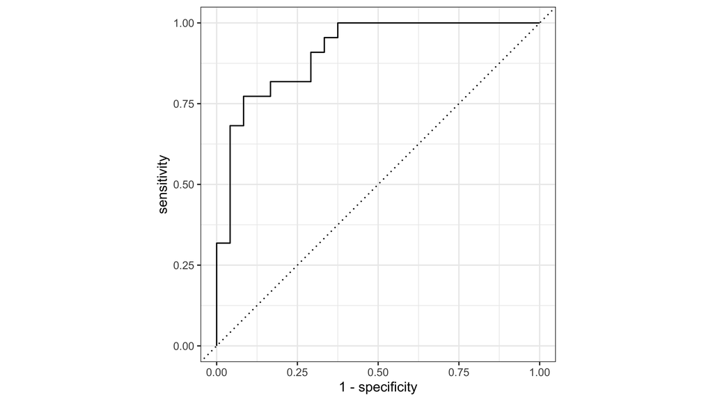

```r
pred_probs |>
  roc_curve(truth = crecimiento_alto, .pred_si, event_level = "second") |>
  autoplot()
```

```r
pred_probs |>
  roc_auc(truth = crecimiento_alto, .pred_si, event_level = "second")
```

```
# A tibble: 1 × 3
  .metric .estimator .estimate
  <chr>   <chr>          <dbl>
1 roc_auc binary         0.911
```

Apéndice 6: Interpretar el AUC

## Más allá de esta sesión

Dos temas que no tocaremos hoy pero aparecen en los apéndices:

- **Comparación de umbrales en detalle**: tabla completa y discusión en Apéndice 4
- **Validación cruzada** (`vfold_cv` + `fit_resamples`): en lugar de una sola división train/test, el modelo se evalúa en varios folds y se promedian las métricas. Da estimaciones más estables. La veremos en Laboratorio 2. Ejemplo en Apéndice 5

Material opcional: carguen el script [`laboratorio-01.R`](https://danilofreire.github.io/introduccion-ia-ucu/clases/dia-01/laboratorio-01.R) para ejecutar todos los ejemplos

# Resumen y cierre

## Lo que aprendimos

**Flujo de trabajo completo:**

1. Cargar y explorar datos
2. Preprocesar (factores, selección)
3. Dividir (train/test con estratificación)
4. Especificar modelo (parsnip)
5. Ajustar (fit)
6. Predecir (predict)
7. Evaluar (métricas, matriz de confusión)

**Conceptos clave:**

- tidymodels unifica el modelado en R
- La estratificación mantiene proporciones de clases
- Las probabilidades dan más información que las clases
- El umbral afecta el balance precision/recall
- La validación cruzada da estimaciones más robustas

## Próximo: Laboratorio 2

En el Laboratorio 2 (Sesión 1.4) vamos a:

- Trabajar con modelos más complejos (árboles de decisión)
- Explorar más a fondo el preprocesamiento
- Comparar múltiples modelos
- Practicar la interpretación de resultados

¡Guarden su trabajo y tómense un descanso! 😉

# Apéndice: Soluciones

## Apéndice 1: Exploración

**Comandos para cada pregunta:**

```r
# 1. Dimensiones del dataset
dim(datos)            # filas y columnas
```

```
[1] 179  11
```

```r
nrow(datos)           # solo filas
```

```
[1] 179
```

```r
ncol(datos)           # solo columnas
```

```
[1] 11
```

```r
# 2. Valores faltantes
sum(is.na(datos))         # total de NAs
```

```
[1] 0
```

```r
colSums(is.na(datos))     # NAs por columna
```

```
                   pais              continente         gasto_educacion
                      0                       0                       0
        acceso_internet            urbanizacion             gasto_salud
                      0                       0                       0
              inflacion               desempleo    inversion_extranjera
                      0                       0                       0
indice_gobierno_digital        crecimiento_alto
                      0                       0
```

```r
# 3. Distribución de variables numéricas
datos |>
  select(where(is.numeric)) |>
  summary()
```

```
 gasto_educacion acceso_internet  urbanizacion    gasto_salud
 Min.   :2.100   Min.   : 5.00   Min.   :16.40   Min.   :3.200
 1st Qu.:4.400   1st Qu.:46.60   1st Qu.:44.70   1st Qu.:5.800
 Median :5.000   Median :57.50   Median :58.10   Median :6.700
 Mean   :5.027   Mean   :57.52   Mean   :58.42   Mean   :6.631
 3rd Qu.:5.600   3rd Qu.:68.35   3rd Qu.:73.15   3rd Qu.:7.450
 Max.   :8.000   Max.   :99.00   Max.   :97.60   Max.   :9.500
   inflacion       desempleo      inversion_extranjera indice_gobierno_digital
 Min.   : 5.20   Min.   : 1.500   Min.   :0.200        Min.   :0.0800
 1st Qu.: 9.35   1st Qu.: 6.700   1st Qu.:3.050        1st Qu.:0.4050
 Median :11.70   Median : 8.400   Median :4.200        Median :0.5200
 Mean   :12.73   Mean   : 8.434   Mean   :4.079        Mean   :0.5136
 3rd Qu.:14.70   3rd Qu.:10.100   3rd Qu.:5.100        3rd Qu.:0.6350
 Max.   :37.40   Max.   :16.100   Max.   :7.400        Max.   :0.9600
```

```r
# 4. Correlaciones entre variables
datos |>
  select(where(is.numeric)) |>
  cor() |>
  round(2)
```

```
                        gasto_educacion acceso_internet urbanizacion
gasto_educacion                    1.00            0.07         0.24
acceso_internet                    0.07            1.00         0.10
urbanizacion                       0.24            0.10         1.00
gasto_salud                        0.26            0.09         0.21
inflacion                         -0.08           -0.05        -0.13
desempleo                         -0.22           -0.13        -0.28
inversion_extranjera               0.21            0.17         0.14
indice_gobierno_digital            0.18            0.20         0.21
                        gasto_salud inflacion desempleo inversion_extranjera
gasto_educacion                0.26     -0.08     -0.22                 0.21
acceso_internet                0.09     -0.05     -0.13                 0.17
urbanizacion                   0.21     -0.13     -0.28                 0.14
gasto_salud                    1.00     -0.17     -0.15                 0.09
inflacion                     -0.17      1.00      0.18                -0.18
desempleo                     -0.15      0.18      1.00                -0.18
inversion_extranjera           0.09     -0.18     -0.18                 1.00
indice_gobierno_digital        0.32     -0.28     -0.30                 0.39
                        indice_gobierno_digital
gasto_educacion                            0.18
acceso_internet                            0.20
urbanizacion                               0.21
gasto_salud                                0.32
inflacion                                 -0.28
desempleo                                 -0.30
inversion_extranjera                       0.39
indice_gobierno_digital                    1.00
```

**Respuestas esperadas:**

- 179 observaciones (un país por fila), 11 variables: `pais`, `continente`, 8 predictores numéricos y `crecimiento_alto`
- 0 valores faltantes: datos simulados. En datos reales esto casi nunca ocurre, siempre verifiquen
- `acceso_internet` y `urbanizacion` tienen distribuciones amplias: países con muy poco acceso vs. muy conectados
- `indice_gobierno_digital` se correlaciona positivamente con `acceso_internet` y negativamente con `inflacion`

Pista: `ggplot2` permite visualizar distribuciones con `geom_histogram()` y correlaciones con el paquete `corrplot` o `ggcorrplot`

Volver al ejercicio

## Apéndice 2: Interpretación

**Calcular las métricas:**

```r
predicciones |>
  precision(truth = crecimiento_alto,
            estimate = .pred_class,
            event_level = "second")
```

```
# A tibble: 1 × 3
  .metric   .estimator .estimate
  <chr>     <chr>          <dbl>
1 precision binary         0.783
```

```r
predicciones |>
  recall(truth = crecimiento_alto,
         estimate = .pred_class,
         event_level = "second")
```

```
# A tibble: 1 × 3
  .metric .estimator .estimate
  <chr>   <chr>          <dbl>
1 recall  binary         0.818
```

```r
# O ambas a la vez:
predicciones |>
  conf_mat(truth = crecimiento_alto,
           estimate = .pred_class) |>
  summary(event_level = "second")
```

```
# A tibble: 13 × 3
   .metric              .estimator .estimate
   <chr>                <chr>          <dbl>
 1 accuracy             binary         0.804
 2 kap                  binary         0.609
 3 sens                 binary         0.818
 4 spec                 binary         0.792
 5 ppv                  binary         0.783
 6 npv                  binary         0.826
 7 mcc                  binary         0.609
 8 j_index              binary         0.610
 9 bal_accuracy         binary         0.805
10 detection_prevalence binary         0.5
11 precision            binary         0.783
12 recall               binary         0.818
13 f_meas               binary         0.8
```

**Cómo interpretar la diferencia:**

- Precisión alta, recall bajo: el modelo predice “crecimiento alto” con cautela. Pocos falsos positivos, pero se pierden casos reales
- Recall alto, precisión baja: predice “sí” con frecuencia. No pierde casos, pero genera más falsas alarmas

**¿Qué métrica priorizar?**

- Si el costo de perder un caso es alto (p. ej., decisiones de inversión): prioricen recall
- Si el costo de una falsa alarma es alto (p. ej., asignar recursos mal): prioricen precisión
- Sin preferencia clara: usen F1 (`f_meas`), el promedio armónico de ambas

No hay respuesta universal. El contexto define la métrica correcta

Volver al ejercicio

## Apéndice 3: Probabilidades

**¿Cómo identificar predicciones inciertas?**

```r
# Observaciones con probabilidad cercana a 0.5
pred_probs |>
  select(crecimiento_alto, .pred_no, .pred_si) |>
  mutate(incertidumbre = abs(.pred_si - 0.5)) |>
  filter(incertidumbre < 0.1) |>
  arrange(incertidumbre)
```

```
# A tibble: 5 × 4
  crecimiento_alto .pred_no .pred_si incertidumbre
  <fct>               <dbl>    <dbl>         <dbl>
1 no                  0.527    0.473        0.0265
2 no                  0.460    0.540        0.0399
3 no                  0.580    0.420        0.0804
4 si                  0.582    0.418        0.0823
5 si                  0.586    0.414        0.0856
```

- Las observaciones con `.pred_si` cercano a 0.5 son las más difíciles de clasificar: pequeños cambios en los predictores pueden cambiar la clase predicha
- En contextos reales, estas observaciones merecen análisis adicional o revisión manual antes de tomar decisiones
- Si hay muchas predicciones inciertas, puede indicar que el modelo necesita más variables o más datos

Volver al ejercicio

## Apéndice 4: Cambio de umbral

```r
# 1. Tres copias de las predicciones, cada una con su umbral
pred_umbrales <- bind_rows(
  pred_probs |> mutate(umbral = 0.3),
  pred_probs |> mutate(umbral = 0.5),
  pred_probs |> mutate(umbral = 0.7)
) |>
  # 2. Clasificar como "si" si la probabilidad supera el umbral de esa copia
  mutate(
    clase_predicha = if_else(.pred_si >= umbral, "si", "no"),
    clase_predicha = factor(clase_predicha, levels = c("no", "si"))
  )

# 3. Calcular precisión y recall dentro de cada umbral
pred_umbrales |>
  group_by(umbral) |>
  summarise(
    precision = precision_vec(crecimiento_alto, clase_predicha,
                              event_level = "second"),
    recall = recall_vec(crecimiento_alto, clase_predicha,
                        event_level = "second")
  )
```

```
# A tibble: 3 × 3
  umbral precision recall
   <dbl>     <dbl>  <dbl>
1    0.3     0.688  1
2    0.5     0.783  0.818
3    0.7     0.85   0.773
```

| Umbral | Precisión | Recall | Interpretación |
| --- | --- | --- | --- |
| 0.3 | baja | alta | predice “sí” fácilmente, más falsos positivos |
| 0.5 | media | media | punto de equilibrio (por defecto) |
| 0.7 | alta | baja | predice “sí” con cautela, más falsos negativos |

Este es el compromiso precisión-recall en acción. El umbral óptimo depende del problema

Volver

## Apéndice 5: Validación cruzada

```r
# Crear los folds para validación cruzada (5 particiones, estratificadas)
set.seed(2026)
folds <- vfold_cv(datos_train, v = 5, strata = crecimiento_alto)

# Ajustar el modelo en cada fold
cv_results <- modelo_log |>
  fit_resamples(
    crecimiento_alto ~ .,
    resamples = folds,
    metrics = metric_set(accuracy, roc_auc),
    control = control_resamples(event_level = "second")
  )

# collect_metrics() devuelve media y error estándar de cada métrica
collect_metrics(cv_results)
```

```
# A tibble: 2 × 6
  .metric  .estimator  mean     n std_err .config
  <chr>    <chr>      <dbl> <int>   <dbl> <chr>
1 accuracy binary     0.759     5  0.0236 pre0_mod0_post0
2 roc_auc  binary     0.864     5  0.0136 pre0_mod0_post0
```

```r
# Comparar con la accuracy de la división única
accuracy(predicciones, truth = crecimiento_alto, estimate = .pred_class)
```

```
# A tibble: 1 × 3
  .metric  .estimator .estimate
  <chr>    <chr>          <dbl>
1 accuracy binary         0.804
```

- `collect_metrics()` devuelve la media de cada métrica sobre los 5 folds junto con su error estándar (`std_err`)
- Un error estándar bajo indica resultados consistentes entre folds (buena señal)
- Si las métricas de CV son peores que las de la división única, la partición original fue demasiado favorable al modelo
- La validación cruzada es más confiable porque cada observación aparece exactamente una vez en validación

Volver

## Apéndice 6: Curva ROC

**Interpretar el AUC:**

| AUC | Interpretación |
| --- | --- |
| 0.5 | No mejor que el azar |
| 0.7–0.8 | Aceptable |
| 0.8–0.9 | Bueno |
| > 0.9 | Excelente (verifiquen data leakage) |

- Una curva que sube rápido al inicio indica que el modelo identifica los positivos más claros primero
- El AUC es independiente del umbral: evalúa el rendimiento en todos los posibles umbrales a la vez
- Es especialmente útil para comparar modelos sin tener que elegir un umbral

Volver al ejercicio

## Apéndice 7: Interpretar los coeficientes

**Recordatorio: regresión logística**

- Los coeficientes están en escala de log-odds
- Un coeficiente positivo aumenta la probabilidad de “sí”
- Un coeficiente negativo la disminuye
- Para convertir a odds ratio: `exp(coeficiente)`

**Pregunta para discutir:**

- ¿Los signos tienen sentido teórico? Por ejemplo, ¿la inflación alta se asocia con menor crecimiento?

```r
# Ver los odds ratios
tidy(ajuste) |>
  mutate(odds_ratio = exp(estimate)) |>
  select(term, estimate, odds_ratio, p.value)
```

```
# A tibble: 9 × 4
  term                    estimate odds_ratio  p.value
  <chr>                      <dbl>      <dbl>    <dbl>
1 (Intercept)             -4.64       0.00963 0.0701
2 gasto_educacion          0.588      1.80    0.0299
3 acceso_internet          0.0634     1.07    0.000658
4 urbanizacion            -0.00648    0.994   0.683
5 gasto_salud             -0.168      0.845   0.443
6 inflacion               -0.166      0.847   0.00938
7 desempleo               -0.318      0.727   0.00438
8 inversion_extranjera     0.355      1.43    0.0505
9 indice_gobierno_digital  5.35     211.      0.00848
```

Volver